# Using rockyIntertidal R pkg.

## Using the rockyIntertidal R package

### This website has been moved to https://doi-nps.github.io/rockyIntertidal and will no longer be updated on this site. The code repo for this site is https://github.com/DOI-NPS/rockyIntertidal.

### Getting started

#### **Step 1.** Install R, RStudio, and RTools44 in Software Center

#### **Step 2.** Install devtools package in R:

```r
install.packages('devtools')
```

#### **Step 3.** Install rockyIntertidal from GitHub

Note that whenever the `rockyIntertidal` package is updated, you can rerun this code to install the latest version.

```r
library(devtools)
install_github("KateMMiller/rockyIntertidal")
```

#### **Step 4.** Load rockyIntertidal R package

```r
library(rockyIntertidal)
```

#### **Step 5.** Import rocky monitoring data

Note that R is not able to connect to files on Sharepoint or MS Teams (b/c Teams also stores all files on Sharepoint). That means you need to store data package files on your local machine or on a server (e.g. NETN Z drive). The default option for importing data will add the data package views (i.e., flatfiles) to an environment called ROCKY to your Environment work space (i.e. Environment tab in top right panel). If you would rather import each individual view into your R session, specify with the new_env argument (e.g., `importData(new_env = F)`). To import data using the default settings (i.e. run `importData()` with no arguments), you must have the rocky intertidal front end set as a User DSN called rocky_FE. The database front end must also be linked with the latest rocky intertidal backend to pull in the latest data (see “Setting up DSN” tab for more details).

**Option 1.** Import data via .csv files. The file path should be where csvs are on your machine or server.

```r
importData(type = 'csv',
           filepath = "C:/NETN/R_Dev/data") # update filepath to your computer
```

**Option 2.** Import data via zip file of csvs. The filepath should be the location and name of the zip file.

```r
importData(type = 'zip',
           filepath = "C:/NETN/R_Dev/data/NETN_RockyIntertidal_Data_Package_20240927.zip")
```

**Option 3.** Import data via data package database file on your computer

```r
importData(type = 'dbfile',
           filepath = "C:/NETN/R_Dev/data/NETN_RockyIntertidal_Database_fe_20240919.accdb")
```

**Option 4.** Import data via data package database DSN (Data Source Name) on your computer. Note that this is the default setting. As long as you have a named DSN called “rocky_FE” that links to the data package database, and that database links to the latest rocky intertidal backend database, the code below will run. See *Setting up DSN* tab for how to set up DSN.

```r
importData() # easiest
importData(type = 'DSN', odbc = "rocky_FE") # equivalent to line above
```

#### **Step 6.** (Optional) Export data package to zip

You can export all of the csvs to a zip file with the day’s date stamped on the file name. This allows you to import the tables from the database, then export the csvs as one zip file.

```r
exportData(filepath = "./data", zip = TRUE)
```

#### **Step 6b.**Import water temperature data *NOTE: NOT RECENTLY TESTED/NOT CURRENTLY ACTIVE*

The water temperature data is stored as separate csvs and so has a different import function and process. The temp logger files will go into your ROCKY environment named the 6 letter location code. The `buoy = T` loads the buoy data for each park to the ROCKY environment. The `simplify = T` simplifies the datasets to include only 1 logger measurement per high tide event (for water temp) and 1 buoy record per day. All plotting functions require the simplified data. The latest compiled files are on the Z drive here: “Z:/PROJECTS/MONITORING/Rocky_Intertidal/NETN/5_Data/Data_Files/Temperature/Compiled_HT_water_temps_2011-2022/”. This reminds me that I need to update the data to include 2023.

```r
#path = "Z:/PROJECTS/MONITORING/Rocky_Intertidal/NETN/5_Data/Data_Files/Temperature/Compiled_HT_water_temps_2011-2022/"
path = "C:/NETN/R_Dev/data/rocky/temp_data/Compiled_HT_water_temps"
importWaterTemp(path = path, buoy = T, simplify = T)
```

#### **Step 7.** Play with the data

The functions in the `rockyIntertidal` package are designed to work with the views, and are the best way to interact with the data to query by park, site, site type, year, parameter, etc. However, if you want to view the raw data, and you imported the data into the ROCKY environment, you can access them with the code below:

```r
# See list of the views
names(ROCKY)

# View one of the views
View(ROCKY$Bolts)

# See top 6 records
head(ROCKY$Echinoderm_Counts)

# Check structure of view
str(ROCKY$Echinoderm_Counts)

# Assign a view to a data frame named bolts in R. Interact with bolts the way you would work with any normal data frame in R.
bolts <- ROCKY$Bolts
```

While this works, the better approach is to use the “getter” functions within the R package, which access the same files, but allow you to also query data based on park, location, years, plot name, species, etc. See the specific getter function tabs for details.

If you want to use the `print_head()` function that shows output in the markdown, run the code below. This makes the results print cleaner in the markdown report. For your purposes, you can just run: `head(dataframe)`.

```r
print_head <- function(df){
  knitr::kable(df[1:6,]) |> #, table.attr = "style='width:60%;'") |>
    kableExtra::kable_classic(full_width = F, font_size = 12,
                              bootstrap_options = c("condensed"))
}
```

#### **Troubleshooting Built Tools:**

If you’re contributing to the package, you’ll need to use build tools to build and install the package to test changes before posting to GitHub. Unfortunately Software Center installs RTools44 in C:/Program Files/, not C:/, which is where RStudio looks for it by default. The following code helps RStudio find RTools. You may occasionally have to rerun this code (except for the usethis line), so keep it handy. You know when you have to rerun the code when you try to rebuild a package, and a window pops up to ask if you want to install missing build files.

```r
# Set r environ to find rtools on opening
usethis::edit_r_environ()
Sys.setenv(PATH = paste("C:\\PROGRA~1\\Rtools44\\bin", Sys.getenv("PATH"), sep=";"))
Sys.setenv(BINPREF = "C:\\PROGRA~1\\Rtools44\\mingw_$(WIN)\\bin\\")
```

#### **Getting (and improving) help**

The functions in `rockyIntertidal` have help documentation like any R package. To view the help, you can go to the Packages tab and click on rockyIntertidal (see below). That will show you all the functions in the package. Clicking on individual functions will take you to the help documentation for that function.

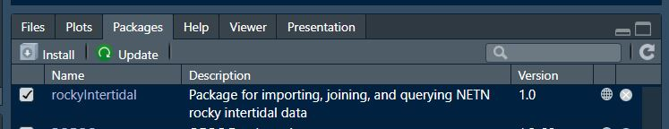

You can also see the help of a function by running, for example:

```r
?importData
```

If `rockyIntertidal` isn’t loaded yet, you’d run:

```r
?rockyIntertidal::importData
```

Each function’s help includes a Description, Usage (i.e. function arguments and their defaults), Argument options/definitions, and several examples showing how the function can be used.

**This is where you come in! If you notice typos or can think of better descriptions, examples, error messages, etc., please send them my way!** After we’re more comfortable with R packages and get versed on GitHub, you’ll be able to make those changes directly in the package. For now, you can just send me your suggestions and I’ll make the changes.

Finally, if you ever want to peak under the hood at the function, you can view it several ways.

1. Keep F2 key pressed and click on the function name in R. This trick works for many but not all functions in R.
2. View code in the [GitHub katemmiller/rockyIntertidal repo](https://github.com/KateMMiller/rockyIntertidal/tree/main). The functions are in the R folder.

#### **Setting up a DSN**

1. Go to Windows Start Menu and search ODBC. Click on ODBC Data Sources (64-bit)

[figure not shown]

2. Click on *Add*, then select *Microsoft Access Driver (*.mdb, *.accdb)* then click *Finish* in next menu.

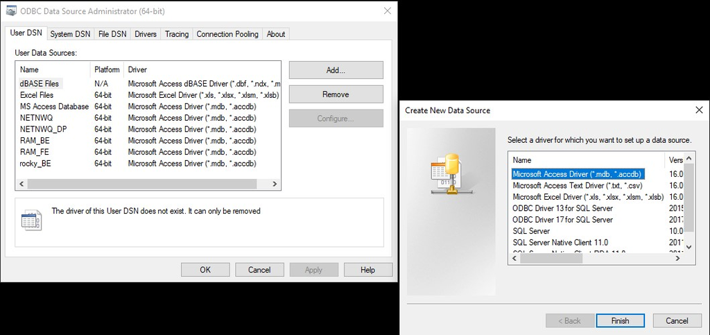

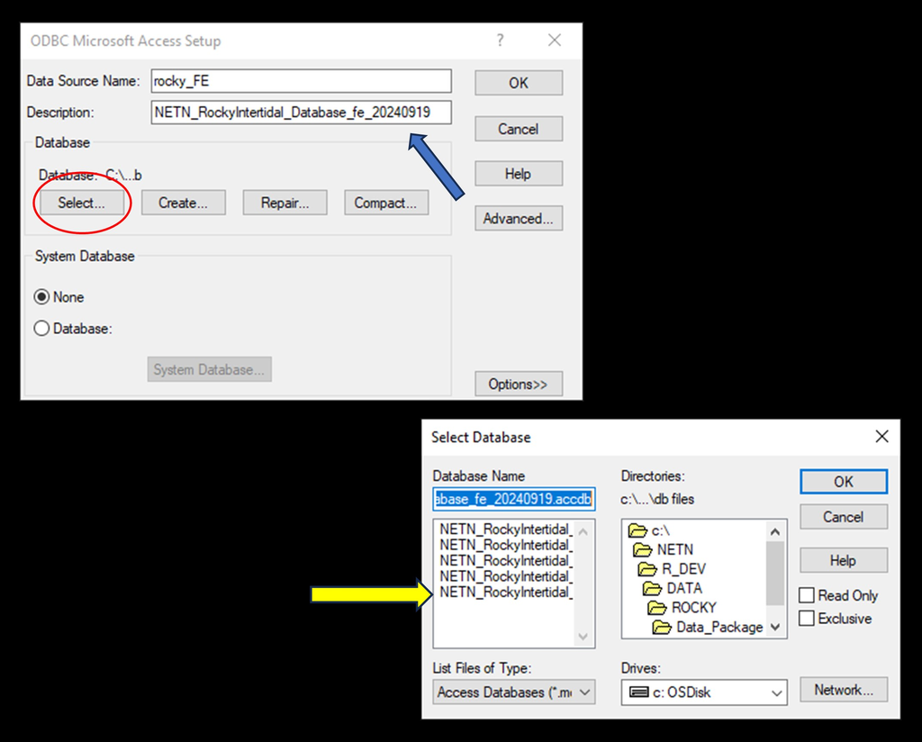

4. If updating an existing DSN, follow similar process, except click on the DSN in the first window and select *Configure* instead of Add.

### get Data functions

#### Bolt data

Get bolt data for ACAD barnacle recruitment plots

```r
print_head(getBolts(park = "ACAD", plotType = "Recruitment Plot"))
```

| GroupCode | GroupName | UnitCode | UnitName | SiteName | SiteCode | Label | PlotName | PlotType | CommunityType | BoltLatitude | BoltLongitude | LatLong_Datum | Bolt_UTM_E | Bolt_UTM_N | Bolt_UTM_Zone | Bolt_UTM_Datum | Bolt_NAVD88_Elev | Bolt_MLLW_Elev | Notes | IsBoltCUI |
| --- | --- | --- | --- | --- | --- | --- | --- | --- | --- | --- | --- | --- | --- | --- | --- | --- | --- | --- | --- | --- |
| NETN | Northeast Temperate Network | ACAD | Acadia National Park | Bass Harbor | BASHAR | S1 bolt 01 | S1 | Recruitment Plot | Barnacle | 44.22448 | -68.32216 | WGS84 | 554148.7 | 4897066 | 19 | NAD83 | 0.453275 | 2.274275 | NA | FALSE |
| NETN | Northeast Temperate Network | ACAD | Acadia National Park | Bass Harbor | BASHAR | S1 bolt 02 | S1 | Recruitment Plot | Barnacle | 44.22448 | -68.32215 | WGS84 | 554148.7 | 4897066 | 19 | NAD83 | 0.475296 | 2.296296 | NA | FALSE |
| NETN | Northeast Temperate Network | ACAD | Acadia National Park | Bass Harbor | BASHAR | S1 label | S1 | Recruitment Plot | Barnacle | 44.22448 | -68.32216 | WGS84 | 554148.7 | 4897066 | 19 | NAD83 | 0.429081 | 2.250081 | NA | FALSE |
| NETN | Northeast Temperate Network | ACAD | Acadia National Park | Bass Harbor | BASHAR | S2 bolt 01 | S2 | Recruitment Plot | Barnacle | 44.22446 | -68.32218 | WGS84 | 554148.7 | 4897066 | 19 | NAD83 | 0.431997 | 2.252997 | NA | FALSE |
| NETN | Northeast Temperate Network | ACAD | Acadia National Park | Bass Harbor | BASHAR | S2 bolt 02 | S2 | Recruitment Plot | Barnacle | 44.22446 | -68.32218 | WGS84 | 554148.7 | 4897066 | 19 | NAD83 | 0.409523 | 2.230523 | NA | FALSE |
| NETN | Northeast Temperate Network | ACAD | Acadia National Park | Bass Harbor | BASHAR | S2 label | S2 | Recruitment Plot | Barnacle | 44.22446 | -68.32218 | WGS84 | 554148.7 | 4897066 | 19 | NAD83 | 0.405884 | 2.226884 | NA | FALSE |

Get bolt data for Calf Island photoplots

```r
print_head(getBolts(site = "CALISL", plotType = "Photoplot"))
```

| GroupCode | GroupName | UnitCode | UnitName | SiteName | SiteCode | Label | PlotName | PlotType | CommunityType | BoltLatitude | BoltLongitude | LatLong_Datum | Bolt_UTM_E | Bolt_UTM_N | Bolt_UTM_Zone | Bolt_UTM_Datum | Bolt_NAVD88_Elev | Bolt_MLLW_Elev | Notes | IsBoltCUI |
| --- | --- | --- | --- | --- | --- | --- | --- | --- | --- | --- | --- | --- | --- | --- | --- | --- | --- | --- | --- | --- |
| NETN | Northeast Temperate Network | BOHA | Boston Harbor Islands National Park Area | Calf Island | CALISL | A1 bolt 01 | A1 | Photoplot | Ascophyllum | 42.34241 | -70.89479 | WGS84 | 343821.4 | 4689574 | 19 | NAD83 | 0.107605 | 1.785605 | NA | FALSE |
| NETN | Northeast Temperate Network | BOHA | Boston Harbor Islands National Park Area | Calf Island | CALISL | A1 bolt 02 | A1 | Photoplot | Ascophyllum | 42.34241 | -70.89478 | WGS84 | 343821.4 | 4689574 | 19 | NAD83 | -0.063546 | 1.614454 | NA | FALSE |
| NETN | Northeast Temperate Network | BOHA | Boston Harbor Islands National Park Area | Calf Island | CALISL | A1 bolt 03 | A1 | Photoplot | Ascophyllum | 42.34241 | -70.89478 | WGS84 | 343821.4 | 4689574 | 19 | NAD83 | -0.140115 | 1.537885 | NA | FALSE |
| NETN | Northeast Temperate Network | BOHA | Boston Harbor Islands National Park Area | Calf Island | CALISL | A1 bolt 04 | A1 | Photoplot | Ascophyllum | 42.34242 | -70.89478 | WGS84 | 343821.4 | 4689574 | 19 | NAD83 | -0.107108 | 1.570892 | NA | FALSE |
| NETN | Northeast Temperate Network | BOHA | Boston Harbor Islands National Park Area | Calf Island | CALISL | A1 label | A1 | Photoplot | Ascophyllum | 42.34241 | -70.89479 | WGS84 | 343821.4 | 4689574 | 19 | NAD83 | 0.095710 | 1.773710 | NA | FALSE |
| NETN | Northeast Temperate Network | BOHA | Boston Harbor Islands National Park Area | Calf Island | CALISL | A2 bolt 01 | A2 | Photoplot | Ascophyllum | 42.34242 | -70.89481 | WGS84 | 343821.4 | 4689574 | 19 | NAD83 | 0.249903 | 1.927903 | NA | FALSE |

#### Barnacle Recruitment

Default filter returns all summer records except QAQC records and blank counts.

```r
print_head(getBarnacleRecruitment())
```

| GroupCode | GroupName | UnitCode | UnitName | SiteCode | SiteName | StartDate | Year | QAQC | QAQCType | PlotName | Count | Notes | DateScored | DateTaken | time_taken | Scorer | IsPointCUI |
| --- | --- | --- | --- | --- | --- | --- | --- | --- | --- | --- | --- | --- | --- | --- | --- | --- | --- |
| NETN | Northeast Temperate Network | ACAD | Acadia National Park | SCHPOI | Schoodic Point | 2013-06-19 | 2013 | FALSE | NA | S1 | 708 | Scoring date not known. | NA | 2013-06-19 | NA | {DB5AAE5D-8B53-4EAF-8DA9-43E7ABB19099} | FALSE |
| NETN | Northeast Temperate Network | ACAD | Acadia National Park | SCHPOI | Schoodic Point | 2013-06-19 | 2013 | FALSE | NA | S2 | 458 | Scoring date not known. | NA | 2013-06-19 | NA | {DB5AAE5D-8B53-4EAF-8DA9-43E7ABB19099} | FALSE |
| NETN | Northeast Temperate Network | ACAD | Acadia National Park | SCHPOI | Schoodic Point | 2013-06-19 | 2013 | FALSE | NA | S3 | 170 | Scoring date not known. | NA | 2013-06-19 | NA | {DB5AAE5D-8B53-4EAF-8DA9-43E7ABB19099} | FALSE |
| NETN | Northeast Temperate Network | ACAD | Acadia National Park | SCHPOI | Schoodic Point | 2013-06-19 | 2013 | FALSE | NA | S4 | 145 | Scoring date not known. | NA | 2013-06-19 | NA | {DB5AAE5D-8B53-4EAF-8DA9-43E7ABB19099} | FALSE |
| NETN | Northeast Temperate Network | ACAD | Acadia National Park | SCHPOI | Schoodic Point | 2013-06-19 | 2013 | FALSE | NA | S5 | 390 | Scoring date not known. | NA | 2013-06-19 | NA | {DB5AAE5D-8B53-4EAF-8DA9-43E7ABB19099} | FALSE |
| NETN | Northeast Temperate Network | ACAD | Acadia National Park | SCHPOI | Schoodic Point | 2013-06-19 | 2013 | FALSE | NA | U1 | 368 | Scoring date not known. | NA | 2013-06-19 | NA | {DB5AAE5D-8B53-4EAF-8DA9-43E7ABB19099} | FALSE |

Barnacle counts for ACAD only sites

```r
print_head(getBarnacleRecruitment(park = "ACAD"))
```

| GroupCode | GroupName | UnitCode | UnitName | SiteCode | SiteName | StartDate | Year | QAQC | QAQCType | PlotName | Count | Notes | DateScored | DateTaken | time_taken | Scorer | IsPointCUI |
| --- | --- | --- | --- | --- | --- | --- | --- | --- | --- | --- | --- | --- | --- | --- | --- | --- | --- |
| NETN | Northeast Temperate Network | ACAD | Acadia National Park | SCHPOI | Schoodic Point | 2013-06-19 | 2013 | FALSE | NA | S1 | 708 | Scoring date not known. | NA | 2013-06-19 | NA | {DB5AAE5D-8B53-4EAF-8DA9-43E7ABB19099} | FALSE |
| NETN | Northeast Temperate Network | ACAD | Acadia National Park | SCHPOI | Schoodic Point | 2013-06-19 | 2013 | FALSE | NA | S2 | 458 | Scoring date not known. | NA | 2013-06-19 | NA | {DB5AAE5D-8B53-4EAF-8DA9-43E7ABB19099} | FALSE |
| NETN | Northeast Temperate Network | ACAD | Acadia National Park | SCHPOI | Schoodic Point | 2013-06-19 | 2013 | FALSE | NA | S3 | 170 | Scoring date not known. | NA | 2013-06-19 | NA | {DB5AAE5D-8B53-4EAF-8DA9-43E7ABB19099} | FALSE |
| NETN | Northeast Temperate Network | ACAD | Acadia National Park | SCHPOI | Schoodic Point | 2013-06-19 | 2013 | FALSE | NA | S4 | 145 | Scoring date not known. | NA | 2013-06-19 | NA | {DB5AAE5D-8B53-4EAF-8DA9-43E7ABB19099} | FALSE |
| NETN | Northeast Temperate Network | ACAD | Acadia National Park | SCHPOI | Schoodic Point | 2013-06-19 | 2013 | FALSE | NA | S5 | 390 | Scoring date not known. | NA | 2013-06-19 | NA | {DB5AAE5D-8B53-4EAF-8DA9-43E7ABB19099} | FALSE |
| NETN | Northeast Temperate Network | ACAD | Acadia National Park | SCHPOI | Schoodic Point | 2013-06-19 | 2013 | FALSE | NA | U1 | 368 | Scoring date not known. | NA | 2013-06-19 | NA | {DB5AAE5D-8B53-4EAF-8DA9-43E7ABB19099} | FALSE |

Barnacle counts for different combinations of parks, sites, plots, and years

```r
barn_sumwin <- getBarnacleRecruitment(park = "ACAD", plotName = "all") # summer and winter counts
barn_BOHA <- getBarnacleRecruitment(park = "BOHA")
barn_5yr <- getBarnacleRecruitment(years = 2016:2021)
barn_first_last <- getBarnacleRecruitment(years = c(2013, 2021))
barn24_qaqc <- getBarnacleRecruitment(years = 2024, QAQC = TRUE)
barn_na <- getBarnacleRecruitment(dropNA = F) # returns NA records too
```

#### Point Intercept Data

Note that the getter functions only return the raw data from the views. Elevation is calculated in `sumPISpecies()`

### PI Bolt Distance

Default returns all records except QAQC visits and blank distances

```r
print_head(getPIBoltDistance())
```

| GroupCode | GroupName | UnitCode | UnitName | SiteCode | SiteName | StartDate | Year | QAQC | PlotName | Label | Elevation_MLLW_m | Distance_m | IsPointCUI |
| --- | --- | --- | --- | --- | --- | --- | --- | --- | --- | --- | --- | --- | --- |
| NETN | Northeast Temperate Network | ACAD | Acadia NP | SCHPOI | Schoodic Point | 2013-06-19 | 2013 | FALSE | T1 | T1 bolt 01 | 3.487006 | 0.00 | FALSE |
| NETN | Northeast Temperate Network | ACAD | Acadia NP | SCHPOI | Schoodic Point | 2013-06-19 | 2013 | FALSE | T1 | T1 bolt 02 | 3.184000 | 1.04 | FALSE |
| NETN | Northeast Temperate Network | ACAD | Acadia NP | SCHPOI | Schoodic Point | 2013-06-19 | 2013 | FALSE | T1 | T1 bolt 03 | NA | 1.53 | FALSE |
| NETN | Northeast Temperate Network | ACAD | Acadia NP | SCHPOI | Schoodic Point | 2013-06-19 | 2013 | FALSE | T1 | T1 bolt 04 | 2.668736 | 3.16 | FALSE |
| NETN | Northeast Temperate Network | ACAD | Acadia NP | SCHPOI | Schoodic Point | 2013-06-19 | 2013 | FALSE | T1 | T1 bolt 05 | 2.543000 | 3.89 | FALSE |
| NETN | Northeast Temperate Network | ACAD | Acadia NP | SCHPOI | Schoodic Point | 2013-06-19 | 2013 | FALSE | T1 | T1 bolt 06 | 2.958020 | 4.95 | FALSE |

PI Bolt distances for different combinations of parks, sites, plots, and years

```r
bolt_na <- getPIBoltDistance(dropNA = F) # return NA records too
bolt_t3 <- getPIBoltDistance(park = "ACAD", plotName = "T3")
bolt_BOHA2 <- getPIBoltDistance(site = c("CALISL", "GREISL"))
bolt_5yr <- getPIBoltDistance(years = 2016:2021)
bolt_first_last <- getPIBoltDistance(years = c(2013, 2021))
bolt_with_qaqc <- getPIBoltDistance(years = 2021, QAQC = TRUE)
```

#### PhotoPlot Cover

Default returns all records except QAQC visits and blank Cover values

```r
print_head(getPhotoCover())
```

| GroupCode | GroupName | UnitCode | UnitName | SiteCode | SiteName | StartDate | Year | QAQC | QAQCType | PlotName | CommunityType | BoltLatitude | BoltLongitude | Bolt_UTM_E | Bolt_UTM_N | Bolt_MLLW_Elev | CoverType | ScientificName | CoverCode | PercentCover | Notes | DateScored | Scorer | IsPointCUI |
| --- | --- | --- | --- | --- | --- | --- | --- | --- | --- | --- | --- | --- | --- | --- | --- | --- | --- | --- | --- | --- | --- | --- | --- | --- |
| NETN | Northeast Temperate Network | ACAD | Acadia National Park | BASHAR | Bass Harbor | 2013-06-21 | 2013 | FALSE | NA | A1 | Ascophyllum | 44.22468 | -68.32274 | 554148.7 | 4897066 | 2.786703 | Other Algae - Red | Rhodophyta | ALGRED | 0 | NA | 2013-09-03 | {1EE29925-05EE-4AEF-967C-2F4D5C2A4724} | FALSE |
| NETN | Northeast Temperate Network | ACAD | Acadia National Park | BASHAR | Bass Harbor | 2013-06-21 | 2013 | FALSE | NA | A1 | Ascophyllum | 44.22468 | -68.32274 | 554148.7 | 4897066 | 2.786703 | Articulated corallines | Corallinales officinalis | ARTCOR | 0 | NA | 2013-09-03 | {1EE29925-05EE-4AEF-967C-2F4D5C2A4724} | FALSE |
| NETN | Northeast Temperate Network | ACAD | Acadia National Park | BASHAR | Bass Harbor | 2013-06-21 | 2013 | FALSE | NA | A1 | Ascophyllum | 44.22468 | -68.32274 | 554148.7 | 4897066 | 2.786703 | Other Invertebrate | Animalia | OTHINV | 0 | NA | 2013-09-03 | {1EE29925-05EE-4AEF-967C-2F4D5C2A4724} | FALSE |
| NETN | Northeast Temperate Network | ACAD | Acadia National Park | BASHAR | Bass Harbor | 2013-06-21 | 2013 | FALSE | NA | A1 | Ascophyllum | 44.22468 | -68.32274 | 554148.7 | 4897066 | 2.786703 | Laver | Porphyra | PORSPP | 0 | NA | 2013-09-03 | {1EE29925-05EE-4AEF-967C-2F4D5C2A4724} | FALSE |
| NETN | Northeast Temperate Network | ACAD | Acadia National Park | BASHAR | Bass Harbor | 2013-06-21 | 2013 | FALSE | NA | A1 | Ascophyllum | 44.22468 | -68.32274 | 554148.7 | 4897066 | 2.786703 | Unidentified | NA | UNIDEN | 0 | NA | 2013-09-03 | {1EE29925-05EE-4AEF-967C-2F4D5C2A4724} | FALSE |
| NETN | Northeast Temperate Network | ACAD | Acadia National Park | BASHAR | Bass Harbor | 2013-06-21 | 2013 | FALSE | NA | A1 | Ascophyllum | 44.22468 | -68.32274 | 554148.7 | 4897066 | 2.786703 | Tar | NA | TAR | 0 | NA | 2013-09-03 | {1EE29925-05EE-4AEF-967C-2F4D5C2A4724} | FALSE |

Photoplot cover for different combinations of parks, sites, plots, years, etc.

```r
cov_na <- getPhotoCover(dropNA = F) # returns NA records too
cov_a1 <- getPhotoCover(park = "ACAD", plotName = "A1")
cov_BOHA2 <- getPhotoCover(site = c("CALISL", "GREISL"))
cov_ab <- getPhotoCover(park = "BOHA", species = c("ALGBRO"))
cov_5yr <- getPhotoCover(years = 2016:2021)
cov_first_last <- getPhotoCover(years = c(2013, 2021))
cov21_with_qaqc <- getPhotoCover(years = 2021, QAQC = TRUE)
```

#### Motile Invert Counts

Default returns all records except QAQC visits and blank counts

```r
print_head(getMotileInvertCounts())
```

| GroupCode | GroupName | UnitCode | UnitName | SiteCode | SiteName | StartDate | Year | QAQC | PlotName | CommunityType | BoltLatitude | BoltLongitude | Bolt_UTM_E | Bolt_UTM_N | Bolt_MLLW_Elev | ScientificName | CommonName | SpeciesCode | Damage | No.Damage | Subsampled | IsPointCUI |
| --- | --- | --- | --- | --- | --- | --- | --- | --- | --- | --- | --- | --- | --- | --- | --- | --- | --- | --- | --- | --- | --- | --- |
| NETN | Northeast Temperate Network | ACAD | Acadia National Park | BASHAR | Bass Harbor | 2013-06-21 | 2013 | FALSE | A1 | Ascophyllum | 44.22468 | -68.32274 | 554148.7 | 4897066 | 2.786703 | Littorina littorea | Common periwinkle | LITLIT | 0 | 3 | No | FALSE |
| NETN | Northeast Temperate Network | ACAD | Acadia National Park | BASHAR | Bass Harbor | 2013-06-21 | 2013 | FALSE | A1 | Ascophyllum | 44.22468 | -68.32274 | 554148.7 | 4897066 | 2.786703 | Littorina obtusata | Smooth periwinkle | LITOBT | 0 | 6 | No | FALSE |
| NETN | Northeast Temperate Network | ACAD | Acadia National Park | BASHAR | Bass Harbor | 2013-06-21 | 2013 | FALSE | A1 | Ascophyllum | 44.22468 | -68.32274 | 554148.7 | 4897066 | 2.786703 | Littorina saxatilis | Rough periwinkle | LITSAX | 0 | 0 | No | FALSE |
| NETN | Northeast Temperate Network | ACAD | Acadia National Park | BASHAR | Bass Harbor | 2013-06-21 | 2013 | FALSE | A1 | Ascophyllum | 44.22468 | -68.32274 | 554148.7 | 4897066 | 2.786703 | Nucella lapillus | Dogwhelk | NUCLAP | 0 | 0 | No | FALSE |
| NETN | Northeast Temperate Network | ACAD | Acadia National Park | BASHAR | Bass Harbor | 2013-06-21 | 2013 | FALSE | A1 | Ascophyllum | 44.22468 | -68.32274 | 554148.7 | 4897066 | 2.786703 | Testudinalia testudinalis | Limpet | TECTES | 0 | 0 | No | FALSE |
| NETN | Northeast Temperate Network | ACAD | Acadia National Park | BASHAR | Bass Harbor | 2014-06-21 | 2014 | FALSE | A1 | Ascophyllum | 44.22468 | -68.32274 | 554148.7 | 4897066 | 2.786703 | Littorina littorea | Common periwinkle | LITLIT | 0 | 2 | No | FALSE |

Motile Invertebrate counts for different combinations of parks, sites, plots, years, etc.

```r
minv_acad <- getMotileInvertCounts(dropNA = F) # return NA counts too
minv_r <- getMotileInvertCounts(park = "ACAD", plotName = c("R1", "R2", "R3", "R4", "R5"))
minv_BOHA2 <- getMotileInvertCounts(site = c("CALISL", "GREISL"))
minv_lit <- getMotileInvertCounts(species = c("LITLIT", "LITOBT", "LITSAX"))
minv_5yr <- getMotileInvertCounts(years = 2016:2021)
minv_first_last <- getMotileInvertCounts(years = c(2013, 2021))
minv21_qaqc <- getMotileInvertCounts(years = 2021, QAQC = TRUE)
```

#### Motile Invert Meas

Default returns all records except QAQC visits and blank counts

```r
print_head(getMotileInvertMeas())
```

| GroupCode | GroupName | UnitCode | UnitName | SiteCode | SiteName | StartDate | Year | QAQC | PlotName | CommunityType | ScientificName | CommonName | SpeciesCode | Measurement | IsPointCUI |
| --- | --- | --- | --- | --- | --- | --- | --- | --- | --- | --- | --- | --- | --- | --- | --- |
| NETN | Northeast Temperate Network | ACAD | Acadia National Park | BASHAR | Bass Harbor | 2013-06-21 | 2013 | FALSE | A1 | Ascophyllum | Littorina littorea | Common periwinkle | LITLIT | 9 | FALSE |
| NETN | Northeast Temperate Network | ACAD | Acadia National Park | BASHAR | Bass Harbor | 2013-06-21 | 2013 | FALSE | A1 | Ascophyllum | Littorina littorea | Common periwinkle | LITLIT | 23 | FALSE |
| NETN | Northeast Temperate Network | ACAD | Acadia National Park | BASHAR | Bass Harbor | 2013-06-21 | 2013 | FALSE | A1 | Ascophyllum | Littorina obtusata | Smooth periwinkle | LITOBT | 12 | FALSE |
| NETN | Northeast Temperate Network | ACAD | Acadia National Park | BASHAR | Bass Harbor | 2013-06-21 | 2013 | FALSE | A1 | Ascophyllum | Littorina obtusata | Smooth periwinkle | LITOBT | 11 | FALSE |
| NETN | Northeast Temperate Network | ACAD | Acadia National Park | BASHAR | Bass Harbor | 2013-06-21 | 2013 | FALSE | A1 | Ascophyllum | Littorina obtusata | Smooth periwinkle | LITOBT | 12 | FALSE |
| NETN | Northeast Temperate Network | ACAD | Acadia National Park | BASHAR | Bass Harbor | 2013-06-21 | 2013 | FALSE | A1 | Ascophyllum | Littorina obtusata | Smooth periwinkle | LITOBT | 12 | FALSE |

Motile Invertebrate measurements for different combinations of parks, sites, plots, years, etc.

```r
minv_acad <- getMotileInvertMeas(park = "ACAD", dropNA = F) # include NA measurements too
minv_r <- getMotileInvertMeas(park = "ACAD", plotName = c("R1", "R2", "R3", "R4", "R5"))
minv_BOHA2 <- getMotileInvertMeas(site = c("CALISL", "GREISL"))
minv_lit <- getMotileInvertMeas(species = c("LITLIT", "LITOBT", "LITSAX"))
minv_5yr <- getMotileInvertMeas(years = 2016:2021)
minv_first_last <- getMotileInvertMeas(years = c(2013, 2021))
minv21_qaqc <- getMotileInvertMeas(years = 2021, QAQC = TRUE)
```

#### Echinoderm Counts

Default returns all records except QAQC visits and blank counts

```r
print_head(getEchinoCounts())
```

| GroupCode | GroupName | UnitCode | UnitName | SiteCode | SiteName | StartDate | Year | QAQC | PlotName | ScientificName | SpeciesCode | Count | IsPointCUI |
| --- | --- | --- | --- | --- | --- | --- | --- | --- | --- | --- | --- | --- | --- |
| NETN | Northeast Temperate Network | ACAD | Acadia National Park | BASHAR | Bass Harbor | 2014-06-21 | 2014 | FALSE | X1 | Henricia sanguinolenta | HENSAN | 0 | FALSE |
| NETN | Northeast Temperate Network | ACAD | Acadia National Park | BASHAR | Bass Harbor | 2014-06-21 | 2014 | FALSE | X1 | Asterias rubens | ASTRUB | 0 | FALSE |
| NETN | Northeast Temperate Network | ACAD | Acadia National Park | BASHAR | Bass Harbor | 2014-06-21 | 2014 | FALSE | X1 | Asterias forbesi | ASTFOR | 0 | FALSE |
| NETN | Northeast Temperate Network | ACAD | Acadia National Park | BASHAR | Bass Harbor | 2014-06-21 | 2014 | FALSE | X1 | Strongylocentrotus droebachiensis | STRDRO | 0 | FALSE |
| NETN | Northeast Temperate Network | ACAD | Acadia National Park | BASHAR | Bass Harbor | 2024-06-29 | 2024 | FALSE | X1 | Asterias forbesi | ASTFOR | 0 | FALSE |
| NETN | Northeast Temperate Network | ACAD | Acadia National Park | BASHAR | Bass Harbor | 2024-06-29 | 2024 | FALSE | X1 | Asterias rubens | ASTRUB | 0 | FALSE |

Echinoderm counts for different combinations of parks, sites, plots, years, etc.

```r
ech_acad <- getEchinoCounts(park = "ACAD", dropNA = F) # return NA counts too
ech_t3 <- getEchinoCounts(park = "ACAD", plotName = "X3")
ech_BOHA2 <- getEchinoCounts(site = c("CALISL", "GREISL"))
ech_5yr <- getEchinoCounts(years = 2016:2021)
ech_first_last <- getEchinoCounts(years = c(2013, 2021))
ech21_qaqc <- getEchinoCounts(years = 2021, QAQC = TRUE)
```

#### Echinoderm Meas

Default returns all records except QAQC visits and blank measurements

```r
print_head(getEchinoMeas())
```

| GroupCode | GroupName | UnitCode | UnitName | SiteCode | SiteName | StartDate | Year | QAQC | PlotName | ScientificName | CommonName | SpeciesCode | Measurement | IsPointCUI |
| --- | --- | --- | --- | --- | --- | --- | --- | --- | --- | --- | --- | --- | --- | --- |
| NETN | Northeast Temperate Network | ACAD | Acadia National Park | BASHAR | Bass Harbor | 2014-06-21 | 2014 | FALSE | X2 | Asterias rubens | Common sea star | ASTRUB | 15 | FALSE |
| NETN | Northeast Temperate Network | ACAD | Acadia National Park | BASHAR | Bass Harbor | 2014-06-21 | 2014 | FALSE | X2 | Strongylocentrotus droebachiensis | Green sea urchin | STRDRO | 33 | FALSE |
| NETN | Northeast Temperate Network | ACAD | Acadia National Park | BASHAR | Bass Harbor | 2014-06-21 | 2014 | FALSE | X2 | Strongylocentrotus droebachiensis | Green sea urchin | STRDRO | 28 | FALSE |
| NETN | Northeast Temperate Network | ACAD | Acadia National Park | BASHAR | Bass Harbor | 2014-06-21 | 2014 | FALSE | X2 | Strongylocentrotus droebachiensis | Green sea urchin | STRDRO | 18 | FALSE |
| NETN | Northeast Temperate Network | ACAD | Acadia National Park | BASHAR | Bass Harbor | 2014-06-21 | 2014 | FALSE | X2 | Strongylocentrotus droebachiensis | Green sea urchin | STRDRO | 48 | FALSE |
| NETN | Northeast Temperate Network | ACAD | Acadia National Park | BASHAR | Bass Harbor | 2014-06-21 | 2014 | FALSE | X2 | Strongylocentrotus droebachiensis | Green sea urchin | STRDRO | 21 | FALSE |

Echinoderm measurements for different combinations of parks, sites, years, etc.

```r
ech_acad <- getEchinoMeas(park = "ACAD", dropNA = F) #returns NAs too
ech_t3 <- getEchinoMeas(park = "ACAD", plotName = "X3")
ech_BOHA2 <- getEchinoMeas(site = c("CALISL", "GREISL"))
ech_5yr <- getEchinoMeas(years = 2016:2021)
ech_first_last <- getEchinoMeas(years = c(2013, 2021))
ech21_qaqc <- getEchinoMeas(years = 2021, QAQC = TRUE)
ech21_ASTFOR <- getEchinoMeas(species = "ASTFOR")
```

### Summarize Data

For every get function, there’s a sum function that summarizes the data. This is typically at the site level for a given species and year. For example, averaging across the 3 point intercept transects, or averaging percent cover across the 5 barnacle photoplots. Summary functions are demonstrated below.

#### Barnacle Recruitment

The barnacle recruitment summary function calculates the median, min and max of counts for a given plot type (ie summer or winter) for each visit. If there are multiple records for a given site x visit x plot type, you will receive a warning in the console with a description of how the duplicates were handled by the function.

```r
print_head(sumBarnacleRecruitment())
```

| GroupCode | GroupName | UnitCode | UnitName | SiteCode | SiteName | StartDate | Year | QAQC | QAQCType | plot_type | median_count | max_count | min_count | num_plots |
| --- | --- | --- | --- | --- | --- | --- | --- | --- | --- | --- | --- | --- | --- | --- |
| NETN | Northeast Temperate Network | ACAD | Acadia National Park | BASHAR | Bass Harbor | 2013-06-21 | 2013 | FALSE | NA | summer | 1260 | 1383 | 1080 | 5 |
| NETN | Northeast Temperate Network | ACAD | Acadia National Park | BASHAR | Bass Harbor | 2013-06-21 | 2013 | FALSE | NA | winter | 1148 | 1247 | 883 | 5 |
| NETN | Northeast Temperate Network | ACAD | Acadia National Park | BASHAR | Bass Harbor | 2014-06-21 | 2014 | FALSE | NA | summer | 1333 | 1430 | 972 | 5 |
| NETN | Northeast Temperate Network | ACAD | Acadia National Park | BASHAR | Bass Harbor | 2014-06-21 | 2014 | FALSE | NA | winter | 573 | 914 | 0 | 5 |
| NETN | Northeast Temperate Network | ACAD | Acadia National Park | BASHAR | Bass Harbor | 2015-06-12 | 2015 | FALSE | NA | summer | 1760 | 2249 | 1722 | 5 |
| NETN | Northeast Temperate Network | ACAD | Acadia National Park | BASHAR | Bass Harbor | 2015-06-12 | 2015 | FALSE | NA | winter | 1256 | 1707 | 780 | 5 |

Summarize different combinations of parks, sites, years, species, etc.

```r
barn_acad <- sumBarnacleRecruitment(park = "ACAD")
barn_summer <- sumBarnacleRecruitment(park = "ACAD", plotName = "summer")
barn_BOHA <- sumBarnacleRecruitment(site = c("CALISL", "GREISL"))
barn_5yr <- sumBarnacleRecruitment(years = 2016:2021)
barn_first_last <- sumBarnacleRecruitment(years = c(2013, 2021))
barn21_qaqc <- sumBarnacleRecruitment(years = 2024, QAQC = TRUE)
```

#### Point Intercept Data

This is the function where elevation is calculated for point intercept distances along the transects. **Note: you will get a warning if there are impossible distance/elevation combinations in the console and an object called bolt_checks will show up in your workspace environment.**

Summarize defaults, which is all parks, all sites, all years, all species, non-QAQC visits, and complete records.

```r
print_head(sumPISpecies())
```

| UnitCode | SiteCode | SiteName | StartDate | QAQC | Year | PlotName | Label | CoverType | CoverCode | Elevation_MLLW_m | elev_first | elev_last | elev_change | Distance_m | PI_Distance | PI_Elevation |
| --- | --- | --- | --- | --- | --- | --- | --- | --- | --- | --- | --- | --- | --- | --- | --- | --- |
| ACAD | BASHAR | Bass Harbor | 2013-06-21 | FALSE | 2013 | T1 | T1 bolt 01 | Rock | ROCK | 4.51103 | 4.51103 | 4.317431 | 0.1935992 | 0 | 0.0 | 4.511030 |
| ACAD | BASHAR | Bass Harbor | 2013-06-21 | FALSE | 2013 | T1 | T1 bolt 01 | Rock | ROCK | 4.51103 | 4.51103 | 4.317431 | 0.1935992 | 0 | 0.3 | 4.486524 |
| ACAD | BASHAR | Bass Harbor | 2013-06-21 | FALSE | 2013 | T1 | T1 bolt 01 | Water | WATER | 4.51103 | 4.51103 | 4.317431 | 0.1935992 | 0 | 0.6 | 4.462018 |
| ACAD | BASHAR | Bass Harbor | 2013-06-21 | FALSE | 2013 | T1 | T1 bolt 01 | Rock | ROCK | 4.51103 | 4.51103 | 4.317431 | 0.1935992 | 0 | 0.9 | 4.437512 |
| ACAD | BASHAR | Bass Harbor | 2013-06-21 | FALSE | 2013 | T1 | T1 bolt 01 | Rock | ROCK | 4.51103 | 4.51103 | 4.317431 | 0.1935992 | 0 | 1.2 | 4.413005 |
| ACAD | BASHAR | Bass Harbor | 2013-06-21 | FALSE | 2013 | T1 | T1 bolt 01 | Rock | ROCK | 4.51103 | 4.51103 | 4.317431 | 0.1935992 | 0 | 1.5 | 4.388499 |

Summarize different combinations of parks, sites, years, species, etc.

```r
spp_ACAD <- sumPISpecies(park = "ACAD")
spp_t3 <- sumPISpecies(park = "ACAD", plotName = "T3")
spp_BOHA2 <- sumPISpecies(site = c("CALISL", "GREISL"))
spp_fuc <- sumPISpecies(park = "BOHA", species = c("FUCEPI", "FUCSPP"))
spp_5yr <- sumPISpecies(years = 2016:2021)
spp_first_last <- sumPISpecies(years = c(2013, 2021))
spp21_with_qaqc <- sumPISpecies(years = 2021, QAQC = TRUE)
spp_no_drops <- sumPISpecies(drop_missing = FALSE)
```

#### PhotoPlot Cover

Summarize defaults, which is all parks, all sites, all plots, all species, all categories, all communities, non-QAQC visits, and complete records.

```r
print_head(sumPhotoCover())
```

| GroupCode | GroupName | UnitCode | UnitName | SiteCode | SiteName | StartDate | Year | QAQC | CommunityType | CoverType | ScientificName | CoverCode | avg_cover | median_cover | min_cover | max_cover | q25_cover | q75_cover |
| --- | --- | --- | --- | --- | --- | --- | --- | --- | --- | --- | --- | --- | --- | --- | --- | --- | --- | --- |
| NETN | Northeast Temperate Network | ACAD | Acadia National Park | BASHAR | Bass Harbor | 2013-06-21 | 2013 | FALSE | Ascophyllum | Articulated corallines | Corallinales officinalis | ARTCOR | 0.0 | 0 | 0 | 0 | 0 | 0 |
| NETN | Northeast Temperate Network | ACAD | Acadia National Park | BASHAR | Bass Harbor | 2013-06-21 | 2013 | FALSE | Ascophyllum | Ascophyllum epibiont | Vertebrata lanosa/Elachista fucicola | ASCEPI | 17.6 | 22 | 2 | 27 | 14 | 23 |
| NETN | Northeast Temperate Network | ACAD | Acadia National Park | BASHAR | Bass Harbor | 2013-06-21 | 2013 | FALSE | Ascophyllum | Barnacle | Semibalanus balanoides | BARSPP | 0.4 | 0 | 0 | 1 | 0 | 1 |
| NETN | Northeast Temperate Network | ACAD | Acadia National Park | BASHAR | Bass Harbor | 2013-06-21 | 2013 | FALSE | Ascophyllum | Crustose coralline | Phymatolithon lenormandii | CRUCOR | 0.0 | 0 | 0 | 0 | 0 | 0 |
| NETN | Northeast Temperate Network | ACAD | Acadia National Park | BASHAR | Bass Harbor | 2013-06-21 | 2013 | FALSE | Ascophyllum | Crustose non-coralline | Calothrix | NONCOR | 0.0 | 0 | 0 | 0 | 0 | 0 |
| NETN | Northeast Temperate Network | ACAD | Acadia National Park | BASHAR | Bass Harbor | 2013-06-21 | 2013 | FALSE | Ascophyllum | Dulse | Palmaria palmata | PALPAL | 0.0 | 0 | 0 | 0 | 0 | 0 |

Summarize different combinations of parks, sites, years, species, etc.

```r
cov_ACAD <- sumPhotoCover(park = "ACAD")
cov_t3 <- sumPhotoCover(park = "ACAD", plotName = "A3")
cov_BOHA2 <- sumPhotoCover(site = c("CALISL", "GREISL"))
cov_ab <- sumPhotoCover(park = "BOHA", species = c("ALGBRO"))
cov_5yr <- sumPhotoCover(years = 2016:2021)
cov23_with_qaqc <- sumPhotoCover(site = "SHIHAR", years = 2023, QAQC = TRUE)
```

#### Motile Invert Counts

This function summarizes site-level average, median, min and max counts by park, site, plot name, and species.

Summarize defaults, which is all parks, all sites, all plots, all species, all communities, non-QAQC visits, and complete records.

```r
print_head(sumMotileInvertCounts())
```

| GroupCode | GroupName | UnitCode | UnitName | SiteCode | SiteName | StartDate | Year | QAQC | CommunityType | SpeciesCode | ScientificName | CommonName | count_total | count_med | count_avg | count_min | count_max | count_l25 | count_u75 | damaged_total | damaged_med | damaged_avg | damaged_min | damaged_max | damaged_l25 | damaged_u75 | notdamaged_total | notdamaged_med | notdamaged_avg | … |
| --- | --- | --- | --- | --- | --- | --- | --- | --- | --- | --- | --- | --- | --- | --- | --- | --- | --- | --- | --- | --- | --- | --- | --- | --- | --- | --- | --- | --- | --- | --- |
| NETN | Northeast Temperate Network | ACAD | Acadia National Park | BASHAR | Bass Harbor | 2013-06-21 | 2013 | FALSE | Ascophyllum | LITLIT | Littorina littorea | Common periwinkle | 70 | 16 | 14.0 | 3 | 23 | 8 | 20 | 1 | 0 | 0.2 | 0 | 1 | 0 | 0 | 69 | 16 | 13.8 | … |
| NETN | Northeast Temperate Network | ACAD | Acadia National Park | BASHAR | Bass Harbor | 2013-06-21 | 2013 | FALSE | Ascophyllum | LITOBT | Littorina obtusata | Smooth periwinkle | 95 | 23 | 19.0 | 6 | 34 | 7 | 25 | 1 | 0 | 0.2 | 0 | 1 | 0 | 0 | 94 | 23 | 18.8 | … |
| NETN | Northeast Temperate Network | ACAD | Acadia National Park | BASHAR | Bass Harbor | 2013-06-21 | 2013 | FALSE | Ascophyllum | LITSAX | Littorina saxatilis | Rough periwinkle | 0 | 0 | 0.0 | 0 | 0 | 0 | 0 | 0 | 0 | 0.0 | 0 | 0 | 0 | 0 | 0 | 0 | 0.0 | … |
| NETN | Northeast Temperate Network | ACAD | Acadia National Park | BASHAR | Bass Harbor | 2013-06-21 | 2013 | FALSE | Ascophyllum | NUCLAP | Nucella lapillus | Dogwhelk | 3 | 0 | 0.6 | 0 | 2 | 0 | 1 | 0 | 0 | 0.0 | 0 | 0 | 0 | 0 | 3 | 0 | 0.6 | … |
| NETN | Northeast Temperate Network | ACAD | Acadia National Park | BASHAR | Bass Harbor | 2013-06-21 | 2013 | FALSE | Ascophyllum | TECTES | Testudinalia testudinalis | Limpet | 0 | 0 | 0.0 | 0 | 0 | 0 | 0 | 0 | 0 | 0.0 | 0 | 0 | 0 | 0 | 0 | 0 | 0.0 | … |
| NETN | Northeast Temperate Network | ACAD | Acadia National Park | BASHAR | Bass Harbor | 2013-06-21 | 2013 | FALSE | Barnacle | LITLIT | Littorina littorea | Common periwinkle | 2 | 0 | 0.4 | 0 | 1 | 0 | 1 | 0 | 0 | 0.0 | 0 | 0 | 0 | 0 | 2 | 0 | 0.4 | … |

Summarize different combinations of parks, sites, years, species, etc.

```r
cnts_acad <- sumMotileInvertCounts (park = "ACAD")
cnt_a1 <- sumMotileInvertCounts (park = "ACAD", plotName = "A1")
cnt_BOHA2 <- sumMotileInvertCounts (site = c("CALISL", "GREISL"))
cnt_gc <- sumMotileInvertCounts (park = "BOHA", species = c("CARMAE"))
cnt_5yr <- sumMotileInvertCounts (years = 2016:2021)
cnt_first_last <- sumMotileInvertCounts (years = c(2013, 2021))
cnt21_with_qaqc <- sumMotileInvertCounts (years = 2021, QAQC = TRUE)
```

#### Motile Invert Meas.

This function summarizes number of individuals in each 5 mm size class by park, site, and species.

Summarize defaults, which is all parks, all sites, all plots, all species, all communities, non-QAQC visits, and complete records.

```r
print_head(sumMotileInvertMeas())
```

| GroupCode | GroupName | UnitCode | UnitName | SiteCode | SiteName | StartDate | Year | QAQC | CommunityType | ScientificName | CommonName | SpeciesCode | Meas_5mm_fac | num_meas |
| --- | --- | --- | --- | --- | --- | --- | --- | --- | --- | --- | --- | --- | --- | --- |
| NETN | Northeast Temperate Network | ACAD | Acadia National Park | BASHAR | Bass Harbor | 2013-06-21 | 2013 | FALSE | Ascophyllum | Littorina littorea | Common periwinkle | LITLIT | 5 to 9.9 | 3 |
| NETN | Northeast Temperate Network | ACAD | Acadia National Park | BASHAR | Bass Harbor | 2013-06-21 | 2013 | FALSE | Ascophyllum | Littorina littorea | Common periwinkle | LITLIT | 10 to 14.9 | 3 |
| NETN | Northeast Temperate Network | ACAD | Acadia National Park | BASHAR | Bass Harbor | 2013-06-21 | 2013 | FALSE | Ascophyllum | Littorina littorea | Common periwinkle | LITLIT | 15 to 19.9 | 23 |
| NETN | Northeast Temperate Network | ACAD | Acadia National Park | BASHAR | Bass Harbor | 2013-06-21 | 2013 | FALSE | Ascophyllum | Littorina littorea | Common periwinkle | LITLIT | 20 to 24.9 | 12 |
| NETN | Northeast Temperate Network | ACAD | Acadia National Park | BASHAR | Bass Harbor | 2013-06-21 | 2013 | FALSE | Ascophyllum | Littorina obtusata | Smooth periwinkle | LITOBT | 5 to 9.9 | 8 |
| NETN | Northeast Temperate Network | ACAD | Acadia National Park | BASHAR | Bass Harbor | 2013-06-21 | 2013 | FALSE | Ascophyllum | Littorina obtusata | Smooth periwinkle | LITOBT | 10 to 14.9 | 35 |

Summarize different combinations of parks, sites, years, species, etc.

```r
minv_acad <- sumMotileInvertMeas(park = "ACAD")
minv_r <- sumMotileInvertMeas(park = "ACAD", plotName = c("R1", "R2", "R3", "R4", "R5"))
minv_BOHA2 <- sumMotileInvertMeas(site = c("CALISL", "GREISL"))
minv_lit <- sumMotileInvertMeas(species = c("LITLIT", "LITOBT", "LITSAX"))
minv_5yr <- sumMotileInvertMeas(years = 2016:2021)
minv_first_last <- sumMotileInvertMeas(years = c(2013, 2021))
minv21_qaqc <- sumMotileInvertMeas(years = 2021, QAQC = TRUE)
```

#### Echinoderm Counts

This function summarizes site-level average, median, min and max counts by park, site, plot name, and species.

Summarize defaults, which is all parks, all sites, all plots, all species, non-QAQC visits, and complete records.

```r
print_head(sumEchinoCounts())
```

| GroupCode | GroupName | UnitCode | UnitName | SiteCode | SiteName | StartDate | Year | QAQC | SpeciesCode | ScientificName | count_total | count_med | count_avg | count_min | count_max | count_l25 | count_u75 |
| --- | --- | --- | --- | --- | --- | --- | --- | --- | --- | --- | --- | --- | --- | --- | --- | --- | --- |
| NETN | Northeast Temperate Network | ACAD | Acadia National Park | BASHAR | Bass Harbor | 2013-06-21 | 2013 | FALSE | ASTFOR | Asterias forbesi | 0 | 0 | 0.0000000 | 0 | 0 | 0 | 0.0 |
| NETN | Northeast Temperate Network | ACAD | Acadia National Park | BASHAR | Bass Harbor | 2013-06-21 | 2013 | FALSE | ASTRUB | Asterias rubens | 0 | 0 | 0.0000000 | 0 | 0 | 0 | 0.0 |
| NETN | Northeast Temperate Network | ACAD | Acadia National Park | BASHAR | Bass Harbor | 2013-06-21 | 2013 | FALSE | HENSAN | Henricia sanguinolenta | 0 | 0 | 0.0000000 | 0 | 0 | 0 | 0.0 |
| NETN | Northeast Temperate Network | ACAD | Acadia National Park | BASHAR | Bass Harbor | 2013-06-21 | 2013 | FALSE | STRDRO | Strongylocentrotus droebachiensis | 0 | 0 | 0.0000000 | 0 | 0 | 0 | 0.0 |
| NETN | Northeast Temperate Network | ACAD | Acadia National Park | BASHAR | Bass Harbor | 2014-06-21 | 2014 | FALSE | ASTFOR | Asterias forbesi | 0 | 0 | 0.0000000 | 0 | 0 | 0 | 0.0 |
| NETN | Northeast Temperate Network | ACAD | Acadia National Park | BASHAR | Bass Harbor | 2014-06-21 | 2014 | FALSE | ASTRUB | Asterias rubens | 1 | 0 | 0.3333333 | 0 | 1 | 0 | 0.5 |

Summarize different combinations of parks, sites, years, species, etc.

```r
cnts_ACAD <- sumEchinoCounts (park = "ACAD")
cnt_a1 <- sumEchinoCounts (park = "ACAD", plotName = "X1")
cnt_BOHA2 <- sumEchinoCounts (site = c("CALISL", "GREISL"))
cnt_af <- sumEchinoCounts (park = "BOHA", species = c("ASTFOR"))
cnt_5yr <- sumEchinoCounts (years = 2016:2021)
cnt_first_last <- sumEchinoCounts (years = c(2013, 2021))
cnt21_with_qaqc <- sumEchinoCounts (years = 2021, QAQC = TRUE)
```

#### Echinoderm Meas

This function summarizes number of individuals in each 5 mm size class by park, site, and species.

Summarize defaults, which is all parks, all sites, all plots, all species, non-QAQC visits, and complete records.

```r
print_head(sumEchinoMeas())
```

| GroupCode | GroupName | UnitCode | UnitName | SiteCode | SiteName | StartDate | Year | QAQC | ScientificName | CommonName | SpeciesCode | Meas_5mm_fac | num_meas |
| --- | --- | --- | --- | --- | --- | --- | --- | --- | --- | --- | --- | --- | --- |
| NETN | Northeast Temperate Network | ACAD | Acadia National Park | BASHAR | Bass Harbor | 2014-06-21 | 2014 | FALSE | Asterias rubens | Common sea star | ASTRUB | 15 to 19.9 | 1 |
| NETN | Northeast Temperate Network | ACAD | Acadia National Park | BASHAR | Bass Harbor | 2014-06-21 | 2014 | FALSE | Strongylocentrotus droebachiensis | Green sea urchin | STRDRO | 15 to 19.9 | 1 |
| NETN | Northeast Temperate Network | ACAD | Acadia National Park | BASHAR | Bass Harbor | 2014-06-21 | 2014 | FALSE | Strongylocentrotus droebachiensis | Green sea urchin | STRDRO | 20 to 24.9 | 1 |
| NETN | Northeast Temperate Network | ACAD | Acadia National Park | BASHAR | Bass Harbor | 2014-06-21 | 2014 | FALSE | Strongylocentrotus droebachiensis | Green sea urchin | STRDRO | 25 to 29.9 | 3 |
| NETN | Northeast Temperate Network | ACAD | Acadia National Park | BASHAR | Bass Harbor | 2014-06-21 | 2014 | FALSE | Strongylocentrotus droebachiensis | Green sea urchin | STRDRO | 30 to 34.9 | 2 |
| NETN | Northeast Temperate Network | ACAD | Acadia National Park | BASHAR | Bass Harbor | 2014-06-21 | 2014 | FALSE | Strongylocentrotus droebachiensis | Green sea urchin | STRDRO | 45 to 49.9 | 1 |

Summarize different combinations of parks, sites, years, species, etc.

```r
minv_acad <- sumEchinoMeas(park = "ACAD")
minv_r <- sumEchinoMeas(park = "ACAD", plotName = c("X1", "X2"))
minv_BOHA2 <- sumEchinoMeas(site = c("CALISL", "GREISL"))
minv_lit <- sumEchinoMeas(species = c("ASTFOR", "ASTRUB"))
minv_5yr <- sumEchinoMeas(years = 2016:2021)
minv_first_last <- sumEchinoMeas(years = c(2013, 2021))
minv21_qaqc <- sumEchinoMeas(years = 2021, QAQC = TRUE)
```

### Plot Data

For most getter and summary functions, there are plotting functions with the same suffix. Some examples are below. See also the examples in the help files for each function.

#### Barnacle Recruitment

This function plots median barnacle recruitment counts across the five summer plots per site and year, with error bars representing min and max counts among the five plots. If only 1 plot is specified, then the raw counts will be plotted. If both summer and winter plots are specified, resulting plot will be color-coded by season. If more than one site and year is specified, results will be faceted by site. **Note that you will receive a warning if there are duplicate count records for a given site, plot name, and visit.**

Plot summer recruitment for all years faceted on ACAD sites

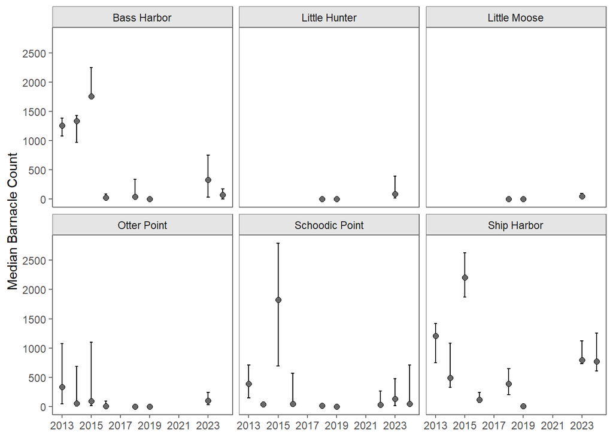

```r
plotBarnacleRecruitment(park = 'ACAD')
```

#### Species Contours

These plots combine the point intercept data (dots and symbols on the graph) and the photoplot cover data (pie charts) to compare changes across years.

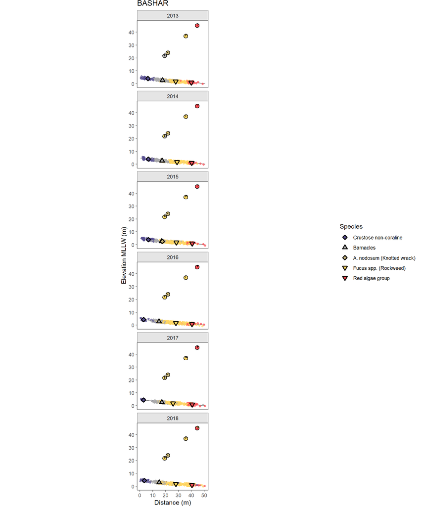

```r
plotSpeciesContours(site = "BASHAR", years = 2013:2018)
```

#### Point Intercept Transect

Plot the transect contours faceted on transect number

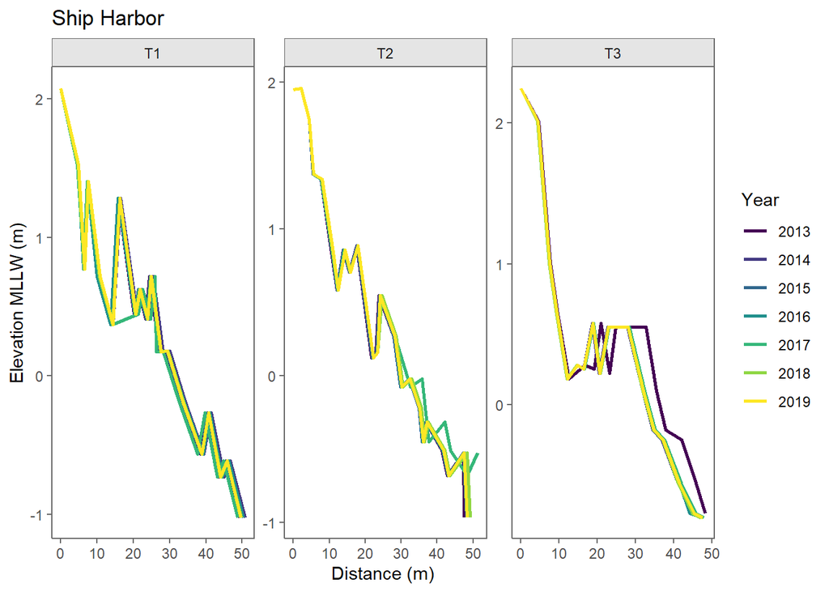

```r
plotPITransects(site = "SHIHAR", years = 2013:2019)
```

#### Point Intercept Species

Plot point intercept species detections summarized as median and middle 50% distribution of elevation. There are a lot of arguments to produce different plots and figures. Some of the ones I find most useful are below. Note when years aren’t specified, all years are included by default.

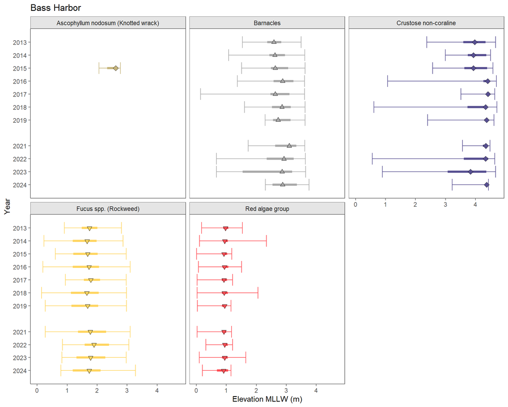

```r
plotPISpecies(site = "BASHAR", facet = T, main_groups = T)
```

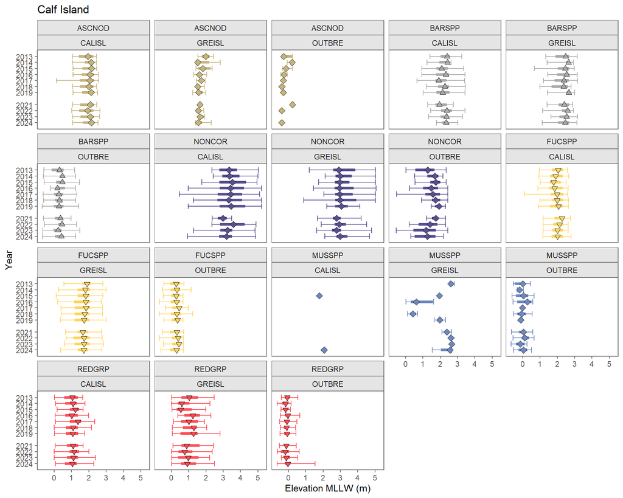

```r
plotPISpecies(park = "BOHA", facet = T, main_groups = T)
```

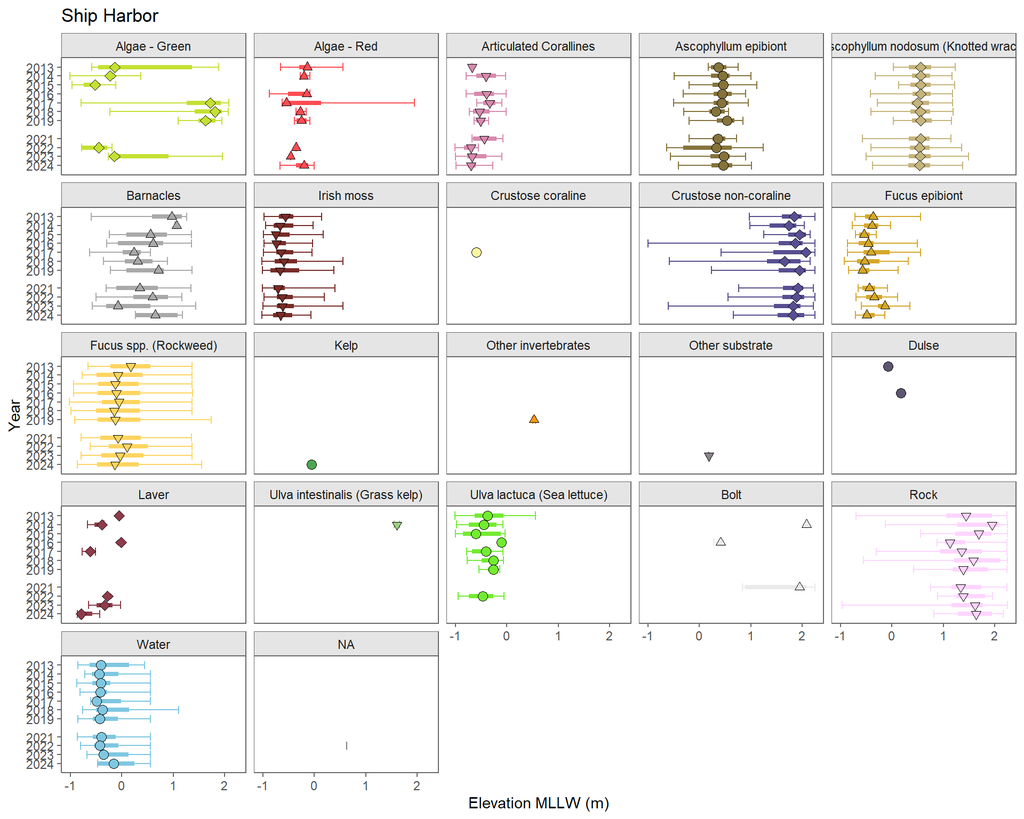

```r
plotPISpecies(site = "SHIHAR", rev_axis = T, facet = T)
```

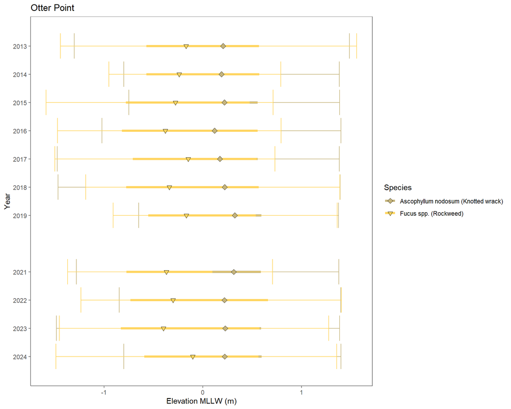

```r
plotPISpecies(site = "OTTPOI", species = c("FUCSPP", "ASCNOD"))
```

#### PhotoPlot Cover

Plots the photoplot cover summarized as median cover and middle 50% distribution of cover across the photoplots within a target species. Note that there are a lot of arguments that produce different plots and figures (all explained in the help). Here are a few I tend to use the most.

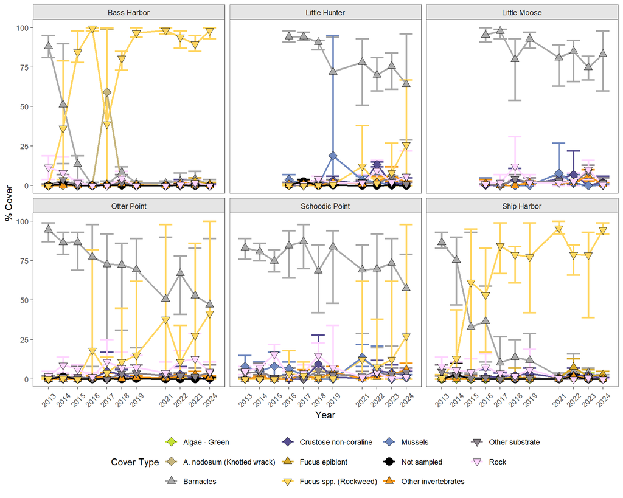

```r
plotPhotoCover(park = "ACAD", community = "Barnacle")
```

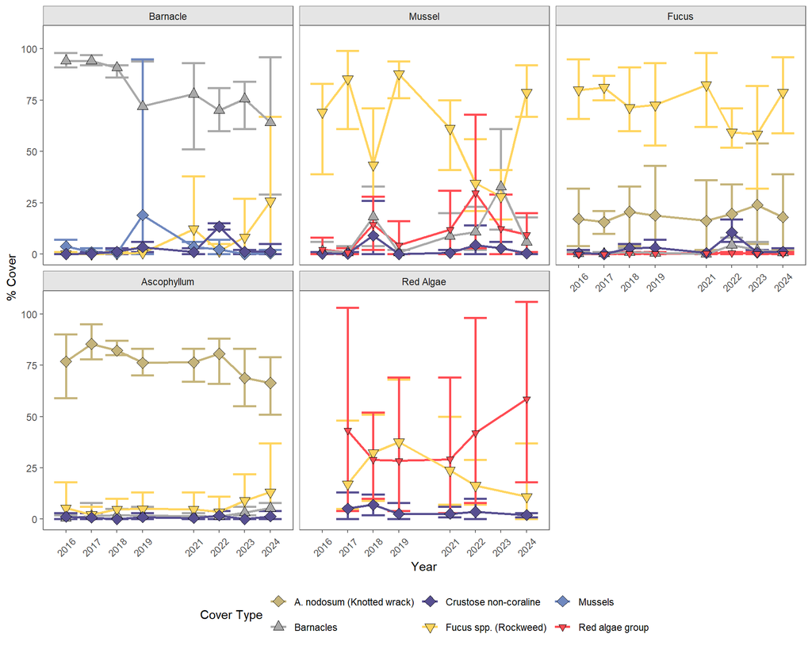

```r
plotPhotoCover(site = "LITHUN", main_groups = T)
```

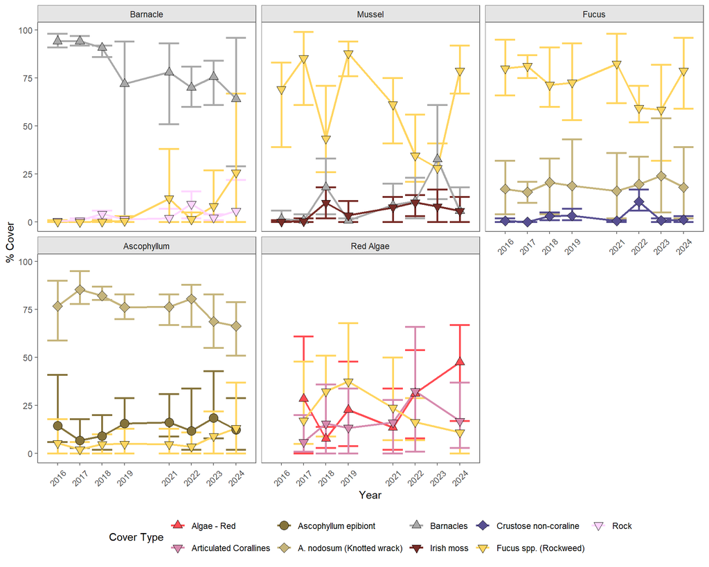

```r
plotPhotoCover(site = "LITHUN", top_spp = 3)
```

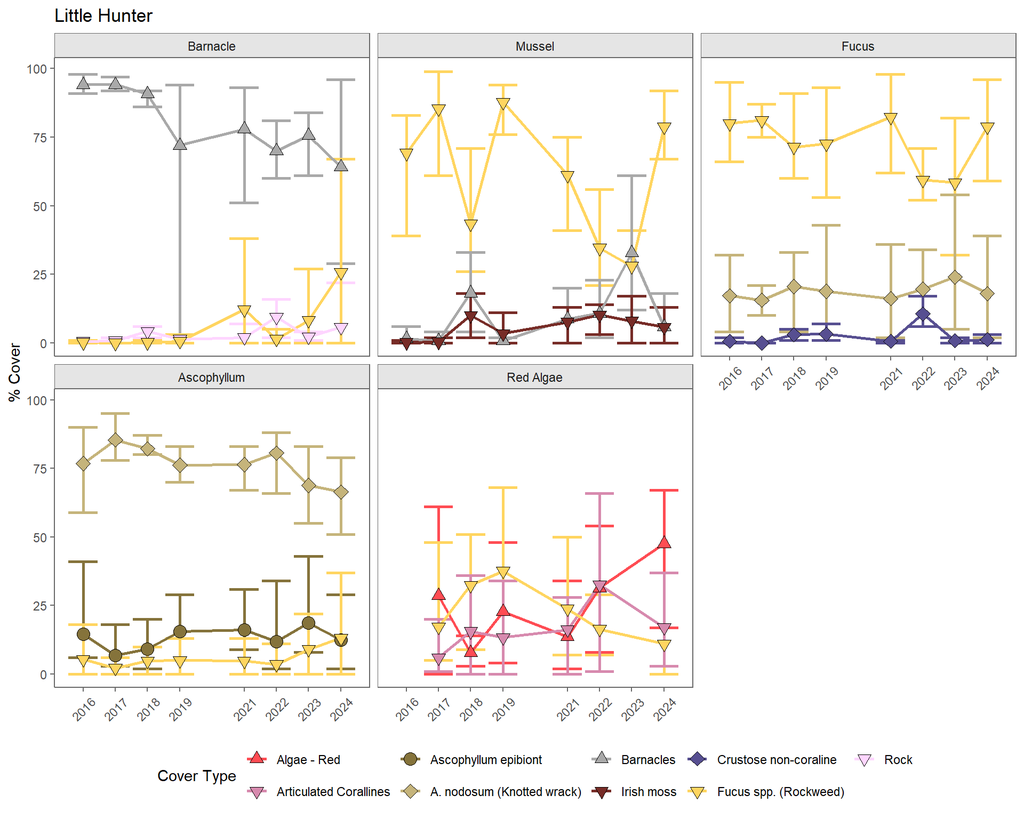

```r
plotPhotoCover(site = "LITHUN", top_spp = 3, xlab = NULL, plot_title = "Little Hunter")
```

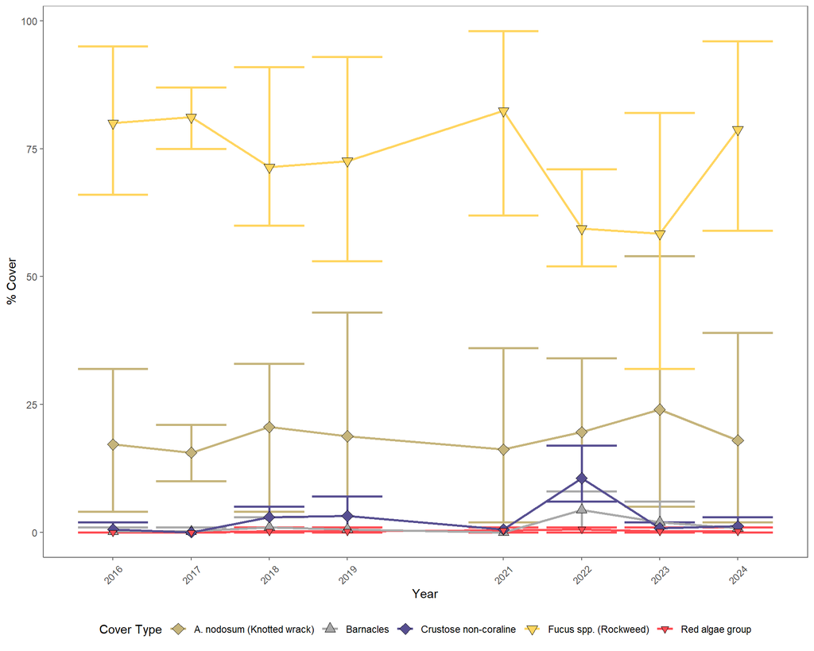

```r
plotPhotoCover(site = "LITHUN", main_groups = T, community = "Fucus")
```

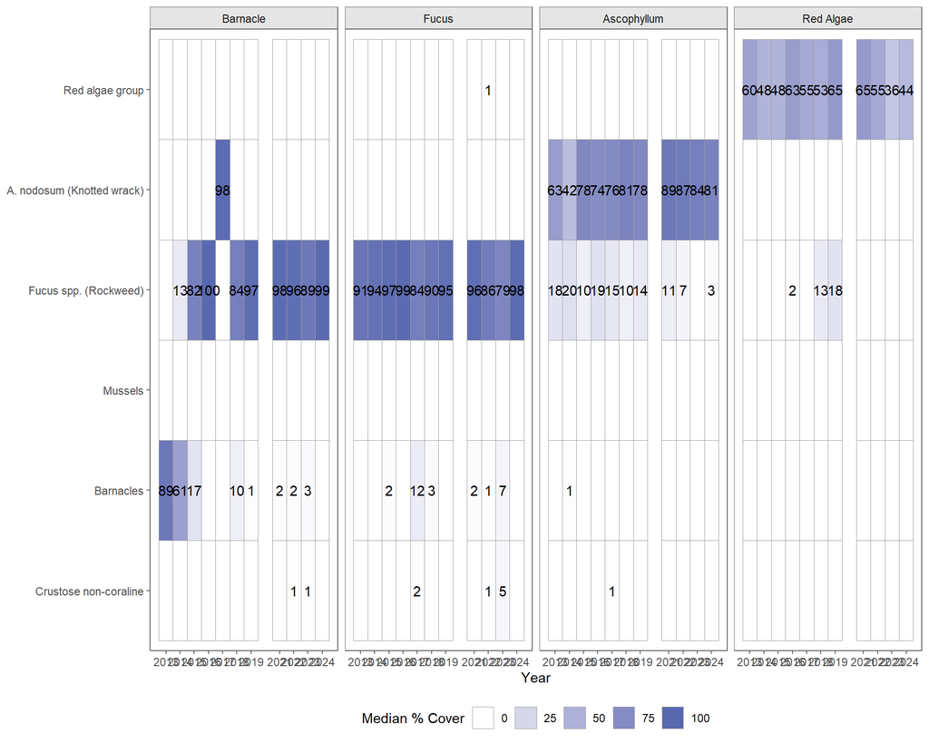

```r
plotPhotoCover(site = "BASHAR", main_groups = T, heatmap = TRUE)
```

#### Motile Invert Counts

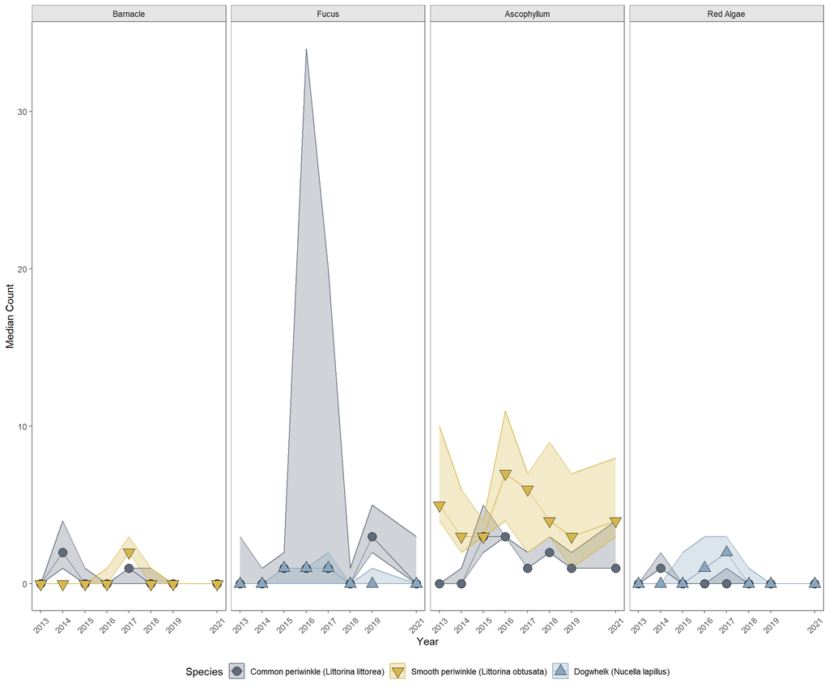

```r
plotMotileInvertCounts(site = "OUTBRE", years = 2013:2021)
```

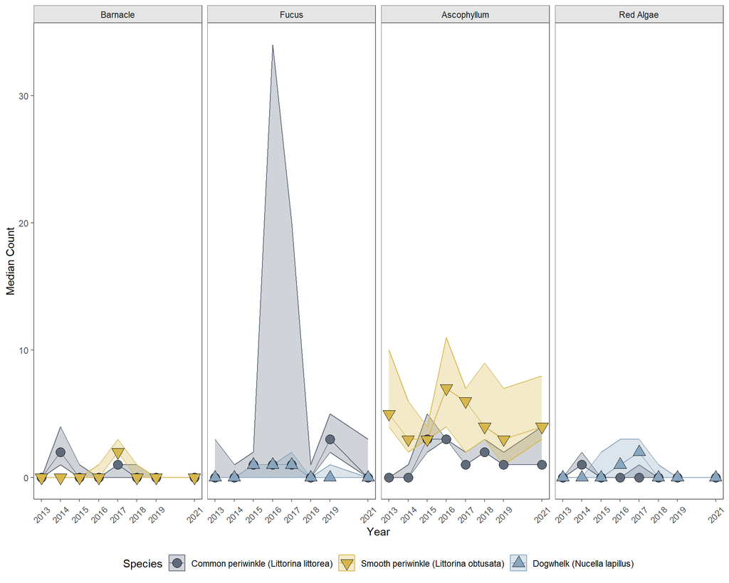

```r
plotMotileInvertCounts(site = "OUTBRE", years = 2013:2021)
```

#### Motile Invet Meas.

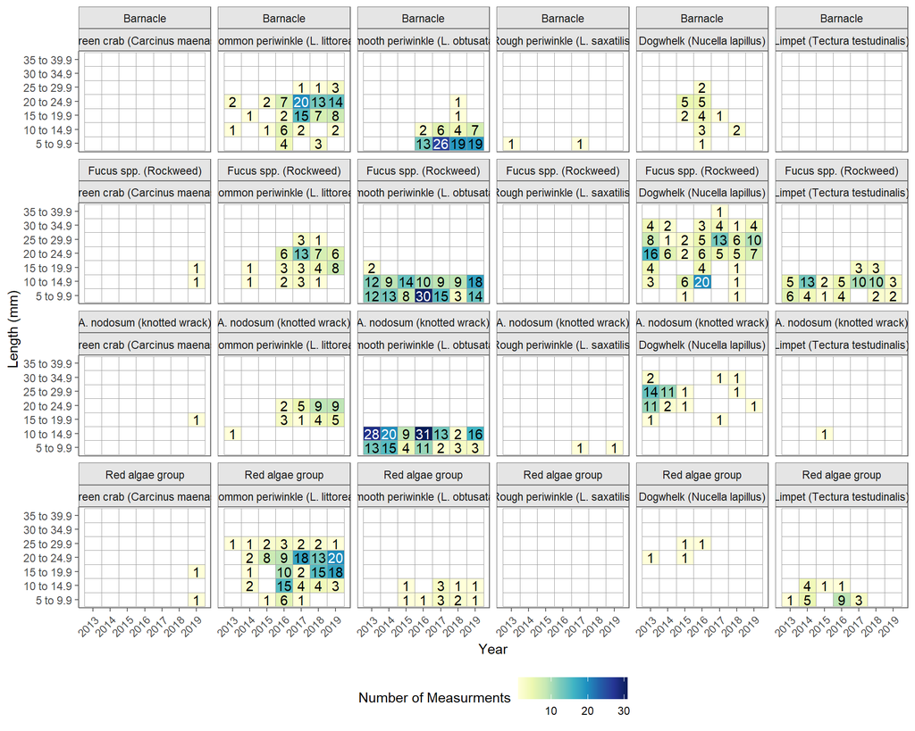

```r
plotMotileInvertMeas(site = "SHIHAR", years = 2013:2019)
```

#### Echinoderm Counts

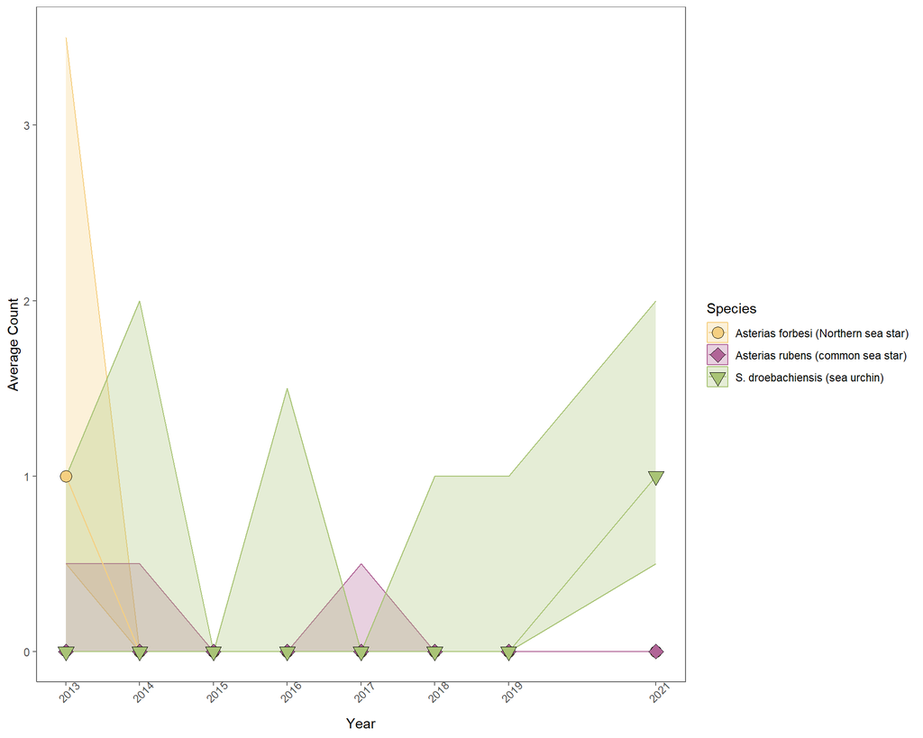

```r
plotEchinoCounts(site = "OUTBRE", years = 2013:2021)
```

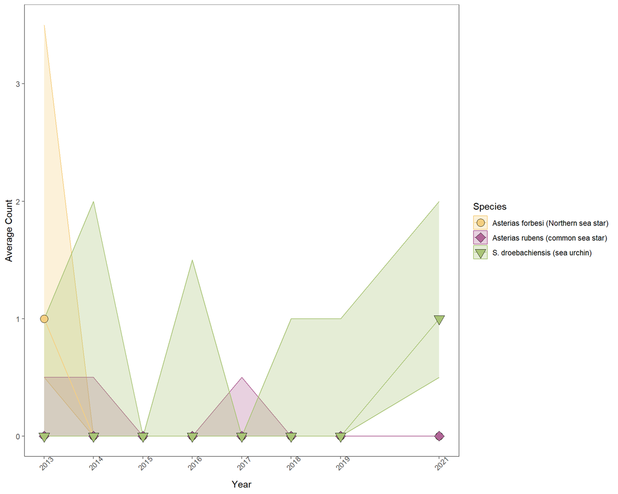

```r
plotEchinoCounts(site = "OUTBRE", years = 2013:2021)
```

#### Echinoderm Meas

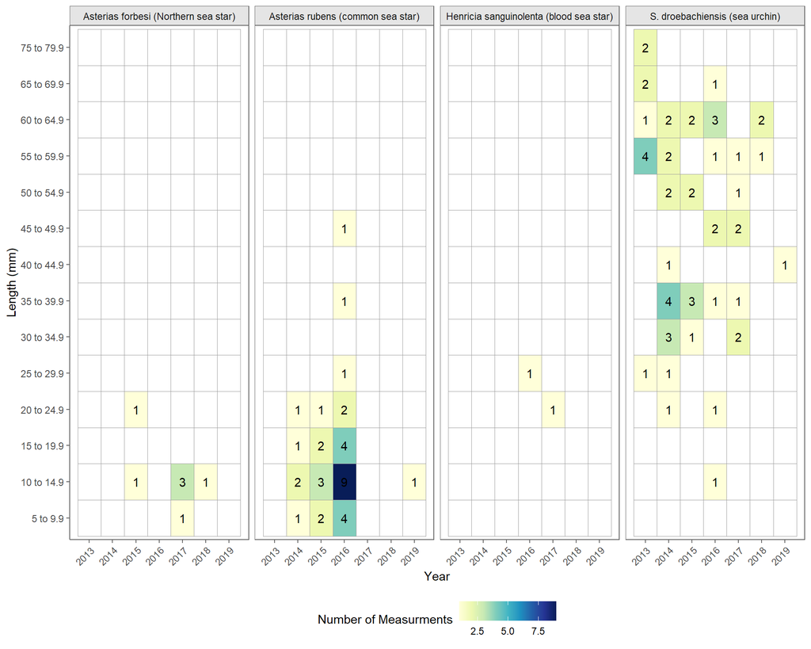

```r
plotEchinoMeas(site = "SHIHAR", years = 2013:2019)
```

#### Water and Buoy Data

**Note the data and functions have not been checked recently. Functions in this section not currently active.**

```r
plotWaterTemp(park = "ACAD", years = 2022, facet_col = 1)
```

```r
plotWaterTemp(site = "BASHAR", years = 2011:2022)
```

```r
plotBuoyData(park = "ACAD", metric = 'all')
```

```r
plotBuoyData(park = "ACAD", metric = "temp", year = 2022)
```

#### Rocky ggplot theme

The default ggplot aesthetics are too busy, and require several lines of code to turn off. For every package, I create a theme that turns those off and can just be run with the ggplot code. For this package use `theme_rocky()` as shown below.

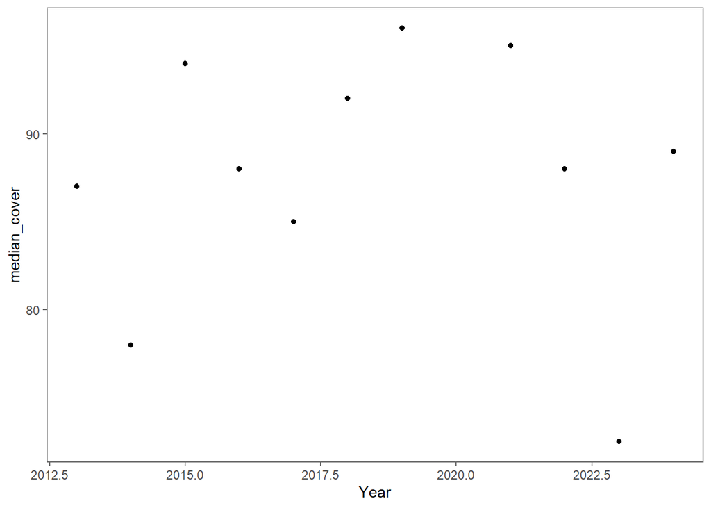

```r
dat <- sumPhotoCover(site = "SHIHAR", community = "Ascophyllum", species = "ASCNOD")

library(ggplot2)
ggplot(dat, aes(x = Year, y = median_cover)) +
  geom_point() +
  theme_rocky()
```